# Insect Visitors and Enviornmental Factors Influence Mango Fruit Production

Mia Fitzgerald and Angela McMahon

4/24/2026

## Introduction

Our data sets were generated from a field study which was conducted on six commercial mango orchards in Australia. The research was to assess the temporal and spacial variations in insect species visiting the orchard and their influence on the mango flowers. Specifically our first data set is looking at the fruit itself and the impact of insect visitation on reproductive success of the flower. This set has a sample size of 85. This set includes some different insect species along with an other category, the total number of insects that visited, what farm they are at, the distance, fruit size in different measurements and the harvest fruit set. Our second data set examines the insect visitors during the night time with a sample size of 85 as well. This data set includes the farm and name as well, along with the time of day, weather conditions, and different insect species seen at those specific conditions. Link to both: https://datadryad.org/dataset/doi:10.5061/dryad.v6wwpzh7p

## Data Import

After downloading the csv files from the link above. Imported the data to R studio, read them in, and stored under fruit_data and nocturnal_visits. The columns names had spaces so we cleaned them using the janitor package to make it compatible with R. Then we made the combined dataset using full_join because they were already in order with the same amount of observations. Join_by helped stop repeat column names and the total variables were renamed for clarity.

```r
fruit_data <- read_csv("Fruit_set.csv") %>% clean_names()
nocturnal_visits <- read_csv("Nocturnal_visits.csv") %>% clean_names()

combined_insect_data <- fruit_data %>%
  full_join(nocturnal_visits, by = join_by(farm, distance)) %>%
  rename(nocturnal_total = total.y, fruit_total = total.x)
```

## Exploratory Data Analysis

### Average Total of Insects Visiting Each Distance

```r
fruit_data %>%
  filter(distance %in% c(0, 50, 100, 150, 200)) %>%
  group_by(distance) %>%
  select(distance, total) %>%
  summarize(avg_total_insects = mean(total, na.rm = TRUE)) %>%
  kable()
```

| distance | avg_total_insects |
| --- | --- |
| 0 | 148.94444 |
| 50 | 50.11111 |
| 100 | 35.33333 |
| 150 | 31.13333 |
| 200 | 23.13333 |

### Total Number of Insect Visitors and Mango Weights

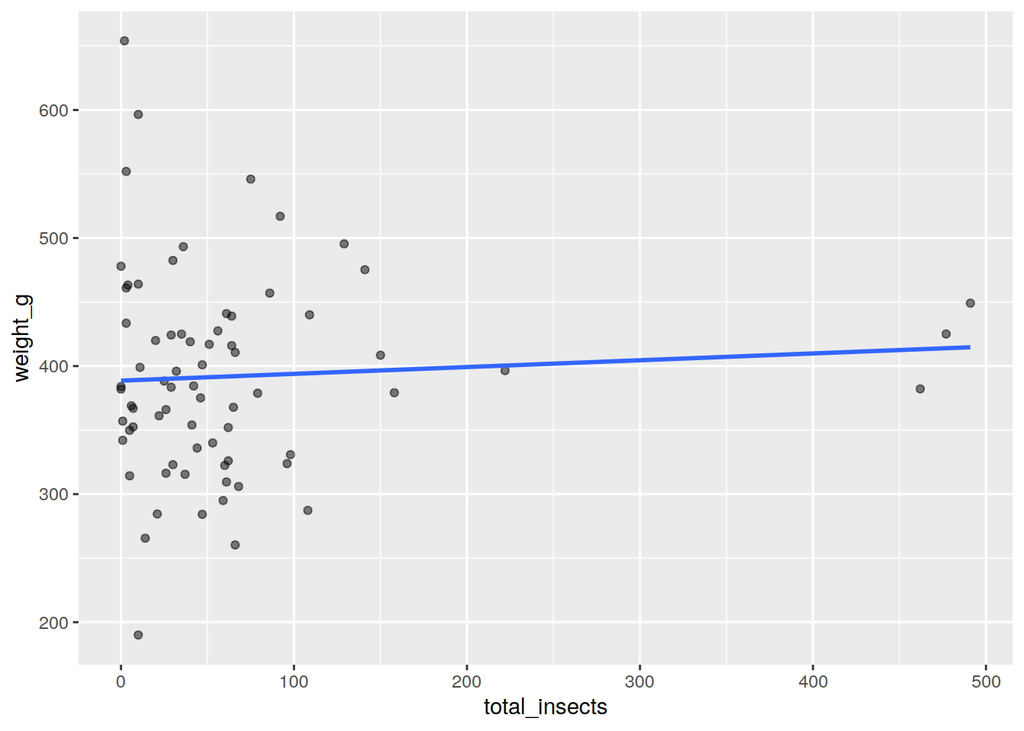

```r
fruit_data %>%
  filter(!is.na(farm)) %>%
  ggplot(aes(x = total, y = weight_g)) +
  geom_point(alpha = 0.5) +
  geom_smooth(method = "lm", se = FALSE) +
  labs(x = "total_insects")
```

### Total Amount of Insects at Each Farm

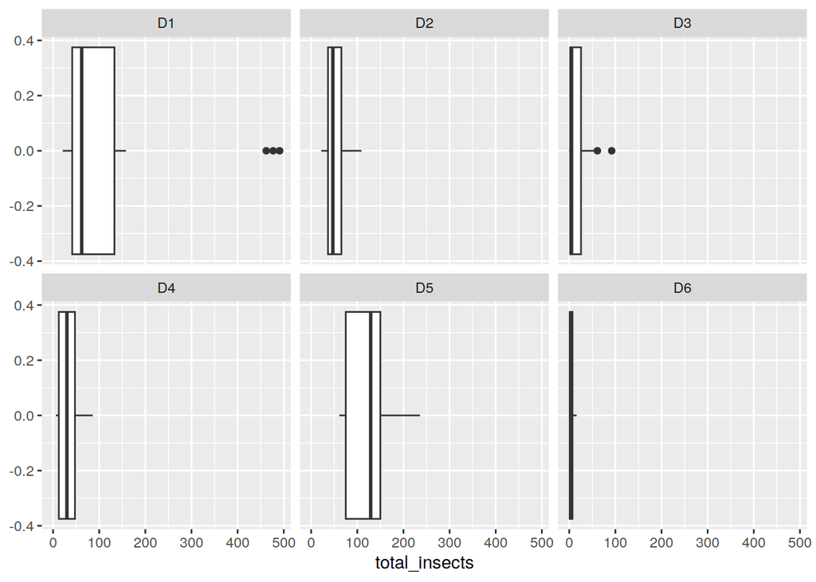

```r
fruit_data %>%
  filter(!is.na(farm)) %>%
  ggplot(aes(x = total)) +
  geom_boxplot() +
  facet_wrap(~farm) +
  labs( x = "total_insects")
```

### Mango Size by Farm

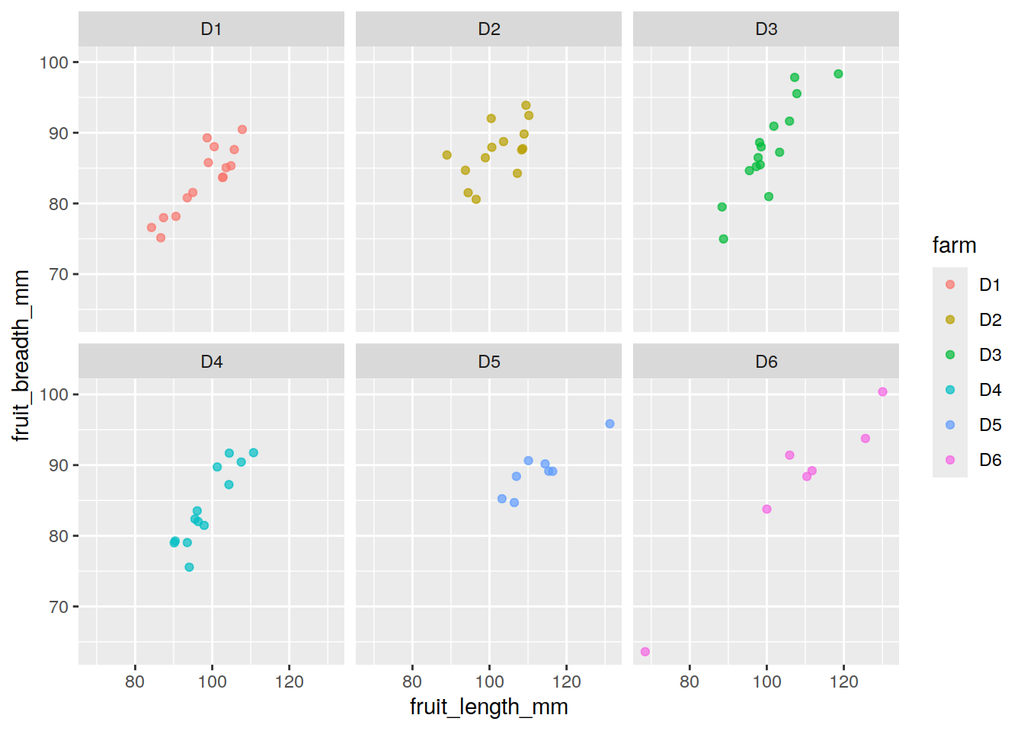

```r
fruit_data%>%
  filter(!is.na(farm))%>%
  ggplot(aes(x=fruit_length_mm, y=fruit_breadth_mm, color=farm))+
  geom_point(alpha=0.7) +
  facet_wrap(~farm)
```

### Average Mango Length and Width in mm

```r
fruit_data%>%
  summarize(avg_length=mean(fruit_length_mm, na.rm=TRUE),
            avg_width=mean(fruit_breadth_mm, na.rm=TRUE)) %>%
  kable()
```

| avg_length | avg_width |
| --- | --- |
| 101.9408 | 86.19431 |

### Total Insects Visiting Each Farm at Night

```r
nocturnal_visits%>%
  filter(!is.na(farm))%>%
  group_by(farm)%>%
  summarize(total_insect=sum(total))%>%
  arrange(desc(total_insect))%>%
  kable()
```

| farm | total_insect |
| --- | --- |
| D5 | 30 |
| D1 | 27 |
| D2 | 25 |
| D3 | 10 |
| D4 | 10 |
| D6 | 0 |

### Humidity and Temp. for each Farm at Night

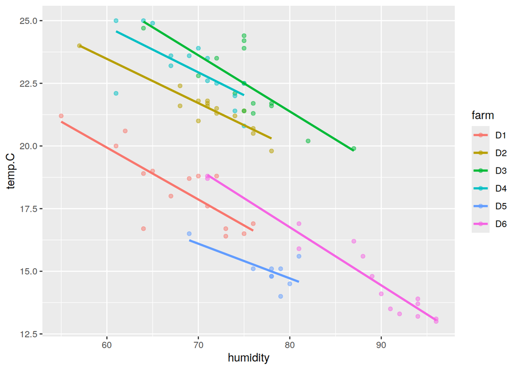

```r
nocturnal_visits%>%
  filter(!is.na(farm))%>%
  rename(humidity=rh, temp.C=temp)%>%
  ggplot(aes(x=humidity, y=temp.C, color=farm))+
  geom_point(alpha=0.5)+
  geom_smooth(method = "lm", se = FALSE)
```

### Average Number of Insects Visiting each Distance at Night

```r
nocturnal_visits%>%
  filter(!is.na(total))%>%
  group_by(distance)%>%
  summarize(avg_insect=round(mean(total),3))%>%
  kable()
```

| distance | avg_insect |
| --- | --- |
| 0 | 4.056 |
| 50 | 0.722 |
| 100 | 0.278 |
| 150 | 0.467 |
| 200 | 0.267 |

### Relative Humidity for each Farm at Night

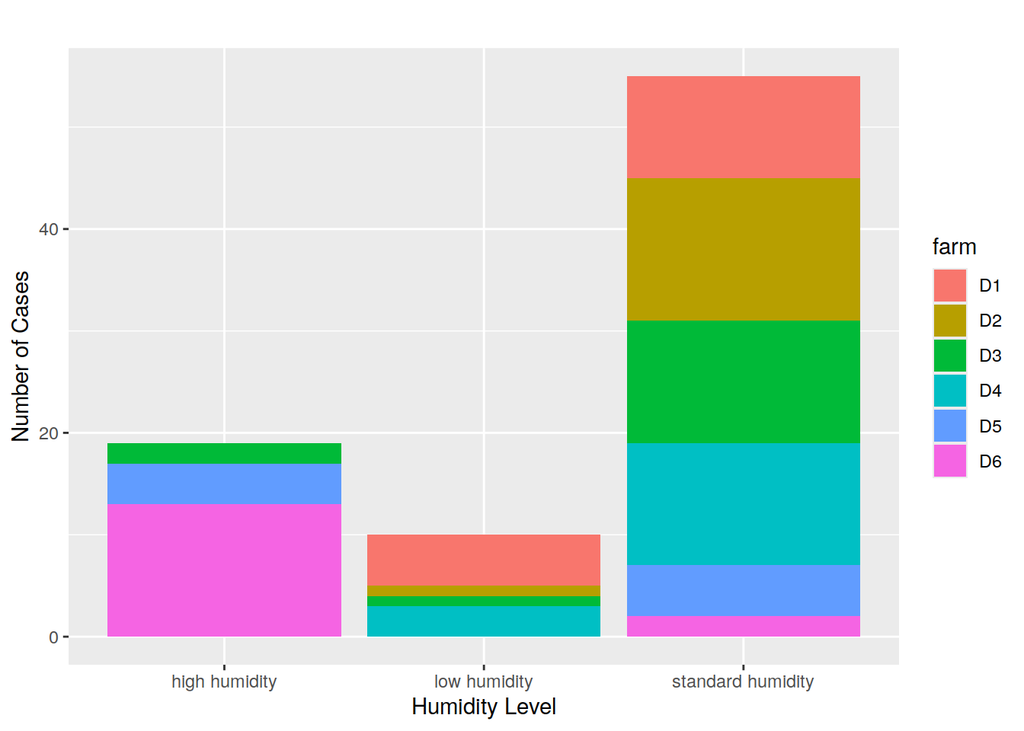

```r
nocturnal_visits%>%
  filter(!is.na(rh))%>%
  mutate(
    humidity= case_when(
      rh<65             ~ "low humidity",
      rh>=65 & rh<79     ~ "standard humidity",
      rh>=79             ~ "high humidity"
    )
  )%>%ggplot(aes(x=humidity, fill=farm))+
  geom_bar()+
  labs(y="Number of Cases", x="Humidity Level", title="")
```

## Research section

### Research Question: Do more or less insects visit the farms with a higher than average humidity at night?

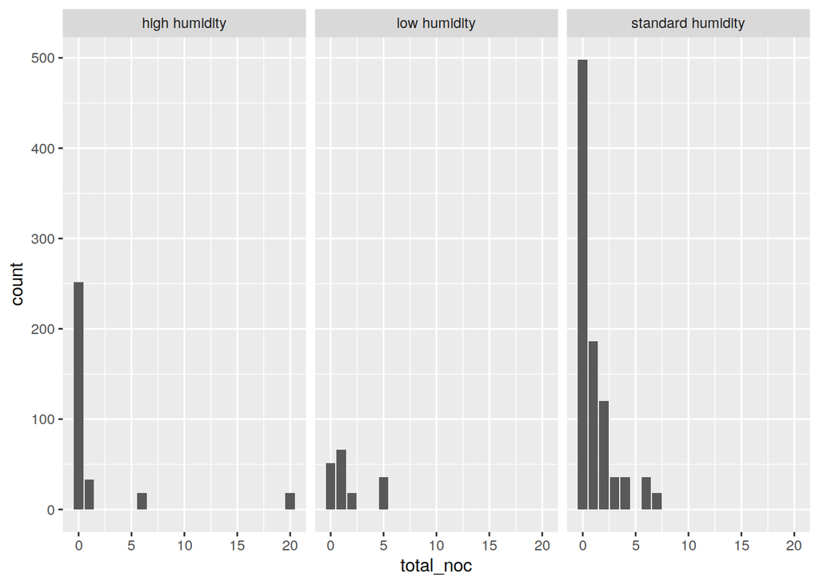

```r
fruit_noc <- fruit_data%>%left_join(nocturnal_visits, join_by(distance))
fruit_noc%>%
  rename(farm=farm.x, total_noc=total.y)%>%
  filter(!is.na(rh))%>%
  mutate(
    humidity= case_when(
      rh<65             ~ "low humidity",
      rh>=65 & rh<79     ~ "standard humidity",
      rh>=79             ~ "high humidity"
    )
  )%>%
  ggplot(aes(x=total_noc))+
  geom_bar()+
  facet_wrap(~humidity)
```